# TASK 1

The diffusion equation is given by:

$$ \frac{\partial \overline B_r}{\partial t} = - \frac{\overline V}{r} \frac{\partial}{\partial r}(r\overline B_r) - \frac{\partial}{\partial z}(\overline V_z \overline B_r) - \frac{\partial}{\partial z}(\alpha \overline B_{\phi}) + \eta_t \left[ \frac{\partial}{\partial r} \left( \frac{1}{r} \frac{\partial}{\partial r}(r \overline B_r)\right) + \frac{\partial ^2 \overline B_r}{\partial z^2} \right] $$$$ \frac{\partial \overline B_{\phi}}{\partial t} = - q\Omega \overline B_{r} - \frac{\partial}{\partial r}(\overline V_r \overline B_{\phi}) - \frac{\partial}{\partial z}(\overline V_z \overline B_{\phi}) + \frac{\partial}{\partial z}(\alpha \overline B_{r}) + \eta_t \left[ \frac{\partial}{\partial r} \left( \frac{1}{r} \frac{\partial}{\partial r}(r \overline B_{\phi})\right) + \frac{\partial ^2 \overline B_{\phi}}{\partial z^2} \right] $$

dimensionless forms of diffusion equation is given by:

$$ \frac{\partial B_r}{\partial t}=-\frac{V_r}{r}\frac{\partial }{\partial r}(r B_r)+\frac{\partial }{\partial z}(V_z B_r)-\frac{\partial }{\partial z}(\alpha B_{\phi})+\frac{\partial }{\partial r}\left(\frac{\partial }{r \partial r}(r B_{\phi})\right)+\frac{\partial^2 B_r}{\partial z ^2} $$$$ \frac{\partial B_{\phi}}{\partial t}=-q\Omega B_r-\frac{\partial }{\partial r}(V_r B_{\phi})+\frac{\partial }{\partial z}(V_z B_{\phi})-\frac{\partial }{\partial z}(\alpha B_r)+\frac{\partial }{\partial r}\left(\frac{\partial }{r \partial r}(r B_{\phi})\right)+\frac{\partial^2 B_r}{\partial z ^2} $$

After omitting the $\nabla \times (\mathbf{V} \times \mathbf{B})$ and $\alpha$ terms, equations are :

$$ \frac{\partial B_r}{\partial t} = \frac{\partial^2 B_r}{\partial z^2} $$$$ \frac{\partial B_{\phi}}{\partial t} = \frac{\partial^2 B_{\phi}}{\partial z^2} $$

### **defining methods**

```python
# Importing necessary libraries
import numpy as np
import matplotlib.pyplot as plt
import scipy
import math


# finite difference method to calculate the second derivative of a function
def d2f(f, dz, Nz):
    sol = np.zeros((Nz))  # Initialize solution array
    for i in range(1, Nz - 2):
        sol[i] = (f[i - 1] - 2 * f[i] + f[i + 1]) / (dz * dz)
    # Apply boundary conditions at i=0
    sol[0] = (2 * f[0] - 5 * f[1] + 4 * f[2] - f[3]) / (dz * dz)
    # Apply boundary conditions at i=Nz-1
    sol[Nz - 1] = (2 * f[Nz - 1] - 5 * f[Nz - 2] + 4 * f[Nz - 3] - f[Nz - 4]) / (dz * dz)
    return sol

# Function to call the second derivative function
def ddf(f,dz,Nz):
    return d2f(f,dz,Nz)

# Runge-Kutta method for time stepping
def solve(f,ddf,dz,Nz,dt,Nt,f_z0,f_zf,time_plot):
    f_plot=[f]  # Initialize array to store function values for plotting
    f_nzby2 = [f[int(Nz/2)]]  # Initialize array to store function values at Nz/2

    # Time stepping loop
    for j in range(1,Nt+1):
        # Calculate Runge-Kutta coefficients
        k1 = ddf(f, dz, Nz)
        k2 = ddf(f, dz, Nz)
        k3 = ddf(f, dz, Nz)
        k4 = ddf(f, dz, Nz)
        # Update function values
        f = f + ((dt / 6.0) * (k1 +( 2 * k2) + (2 * k3) + k4))
        # Apply boundary conditions
        f[0]=f_z0
        f[Nz-1]=f_zf

        # Store function value at Nz/2
        f_nzby2.append(f[int(Nz/2)])

        # Store function values for specified time steps
        if j in time_plot:
            f_plot.append(f)

    # Return arrays for plotting
    return np.array(f_plot),np.array(f_nzby2)
```

### **Implementing and plotting the result**

Initial functions used are:

- $B_r(t_0,z)=f_{1_{t0}}(z) = 6\sin\left(\frac{\pi z}{2}\right)$
- $B_{\phi}(t_0,z)=f_{2_{t0}}(z) = 6\sin\left(\frac{\pi z}{2}\right) + \sin(3\pi z)$

##### **pitch angle:**

$\arctan \left( \frac{B_r}{B_{\phi}} \right)$ is the pitch angle and it plotted against z at different time points

##### **exponential decay rate:**

$\log \left( \sqrt{ (B_{\phi})^2 + (B_r)^2 } \right)$ is poltted against time at specific z. The slope from linear fit is the exponential decay rate. Here z is taken as the middle value over spatial domain

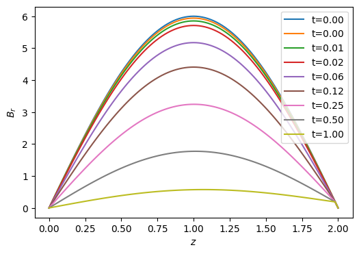

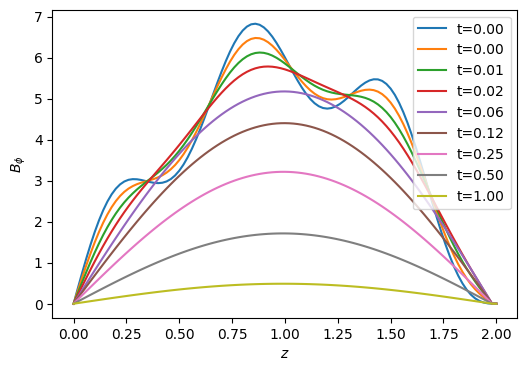

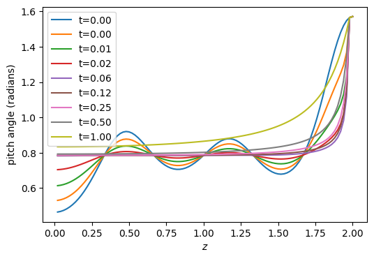

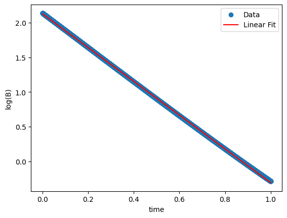

```
Fitted equation: y = -2.4348t + 2.1276
exponential decay constant: -2.4348
```

```python
# Define initial functions f2_t0 and f1_t0
def f2_t0(z):
    return 6*np.sin((np.pi)*z/2)+np.sin(np.pi*z*3)

def f1_t0(z):
    return 6*np.sin((np.pi)*z/2)

# Define variables
z0 = 0  # start of spatial region in z
zf = 2  # end of spatial region in z
t0 = 0  # start of time region
tf = 1  # end of time region
Nz = 101  # number of spatial grid points
Nt = 10000  # number of time points
z = np.linspace(z0, zf, Nz)  # spatial grid points

# Initial conditions for functions f1 and f2 at time t0 for all z
f1_t0_inz = f1_t0(z)
f2_t0_inz = f2_t0(z)

# Initial conditions for functions f1 and f2 at z0 and zf
f1_z0=f1_t0(z0)
f1_zf=f1_t0(zf)
f2_z0=f2_t0(z0)
f2_zf=f2_t0(zf)

dz = (zf - z0) / (Nz - 1)  # spatial step size
dt = (tf -t0)/ Nt  # time step size

# Time points at which we want to plot the solution
time_plot=[0,40,100,200,600,Nt/8,Nt/4,Nt/2,Nt]

# Time grid points
time = np.linspace(0, (tf-t0), Nt+1)
# Solve equations using solve function
f1_plot,f1_nzby2 = solve(f1_t0_inz,ddf,dz,Nz,dt,Nt,f1_z0,f1_zf,time_plot)
f2_plot,f2_nzby2= solve(f2_t0_inz,ddf,dz,Nz,dt,Nt,f2_z0,f2_zf,time_plot)

# Calculate decay and pitch
decay = np.log(np.sqrt(f1_nzby2**2 + f2_nzby2**2))
pitch=np.arctan(f1_plot/f2_plot)

# Plot B_r vs z
fig, ax = plt.subplots(1, 1, figsize=(6, 4))
for m in range(len(time_plot)):
    ax.plot(z, f1_plot[m], label=f't={time_plot[m] * dt:.2f}')
ax.set_xlabel(r'$z$')
ax.set_ylabel(r'$B_r$')
ax.legend()
plt.show()

# Plot B_phi vs z
fig, ax = plt.subplots(1, 1, figsize=(6, 4))
for m in range(len(time_plot)):
    ax.plot(z, f2_plot[m], label=f't={time_plot[m] * dt:.2f}')
ax.set_xlabel(r'$z$')
ax.set_ylabel(r'$B_{\phi}$')
ax.legend()
plt.show()

# Plot pitch angle vs z
fig, ax = plt.subplots(1, 1, figsize=(6, 4))
for m in range(len(time_plot)):
    ax.plot(z, pitch[m], label=f't={time_plot[m] * dt:.2f}')
ax.set_xlabel(r'$z$')
ax.set_ylabel(r'pitch angle (radians)')
plt.title('Pitch angle vs z')
ax.legend()
plt.show()

# Perform linear regression
coefficients = np.polyfit(time, decay, 1)  # Fit a first-degree polynomial (linear fit)
slope, intercept = coefficients

# Generate the fitted line
fit_x = np.linspace(min(time), max(time), 100)
fit_y = np.polyval(coefficients, fit_x)

# Plot the data points and the fitted line
plt.scatter(time, decay, label='Data')  # Plot data points
plt.plot(fit_x, fit_y, color='red', label='Linear Fit')  # Plot fitted line
plt.xlabel('time')
plt.ylabel('log(B)')
plt.legend()
plt.title('exponential decay rate')
plt.show()

# Print the fitted equation
equation = f'y = {slope:.4f}t + {intercept:.4f}'
print('Fitted equation:', equation)
print('exponential decay constant:', round(slope,4))
```

#### **Analyzing for different initial functions and boundary conditions**

Initial functions are:

- $ f_{3}(t_0,z) = 5e^{-3z}$
- $ f_{4}(t_0,z) = 6z^3 + 4\sin(4\pi z)$

spatial grid points and time grid points are same as above

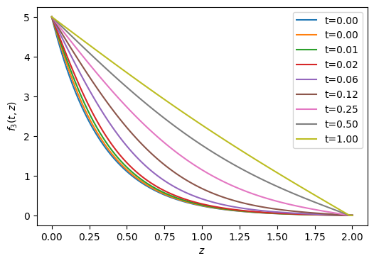

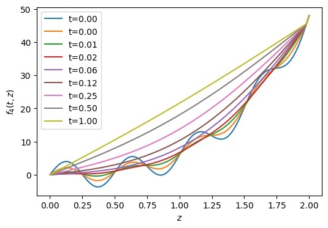

```python
# Define the function f3_t0
def f3_t0(z):
    return 5*(np.exp(3*-z))

# Define the function f4_t0
def f4_t0(z):
    return 6*(z**3)+4*np.sin(4*np.pi*z)

# Calculate the initial conditions for f3 and f4 over the spatial domain
f3_t0_inz = f3_t0(z)
f4_t0_inz = f4_t0(z)

# Calculate the boundary condition of the spatial domain for f3 and f4
f3_z0=f3_t0(z0)
f4_z0=f4_t0(z0)
f3_zf=f3_t0(zf)
f4_zf=f4_t0(zf)

# Solve the differential equation
f3_plot,f3_nzby2 = solve(f3_t0_inz,ddf,dz,Nz,dt,Nt,f3_z0,f3_zf,time_plot)
f4_plot,f4_nzby2= solve(f4_t0_inz,ddf,dz,Nz,dt,Nt,f4_z0,f4_zf,time_plot)

# Plot the solution for f3 at different time steps
fig, ax = plt.subplots(1, 1, figsize=(6, 4))
for m in range(len(time_plot)):
    ax.plot(z, f3_plot[m], label=f't={time_plot[m] * dt:.2f}')
ax.set_xlabel(r'$z$')  # Label for the x-axis
ax.set_ylabel(r'$f_{3}(t,z)$')  # Label for the y-axis
ax.legend()  # Show the legend
plt.show()  # Display the plot

# Plot the solution for f4 at different time steps
fig, ax = plt.subplots(1, 1, figsize=(6, 4))
for m in range(len(time_plot)):
    ax.plot(z, f4_plot[m], label=f't={time_plot[m] * dt:.2f}')
ax.set_xlabel(r'$z$')  # Label for the x-axis
ax.set_ylabel(r'$f_{4}(t,z)$')  # Label for the y-axis
ax.legend()  # Show the legend
plt.show()  # Display the plot
```